# Assignment #1

Jeremy Yeaton

November 25, 2017

Disclaimer: I’m pretty confident that my R code is sound throughout, but I am drastically less confident in my explanations and interpretations.

# Question 1:

1. *Give a numerical summary of FEV1 (mean, standard deviation and range) for each smoking category (recoded as a categorical variable with appropriate levels), and for all subjects (grand mean and overall standard deviation). Results should be printed in one or two Tables.*

The table below shows the descriptive statistics for each of the groups:

| cat.f | mean | sd | range |
| --- | --- | --- | --- |
| current | 3.220000 | 0.6758106 | 1.82 |
| early | 3.938333 | 0.2545912 | 0.69 |
| non-smoker | 4.220000 | 0.5726081 | 1.46 |
| recent | 3.460000 | 0.7128534 | 2.12 |

And descriptive statistics of all of the data together:

| grand mean | overall sd | total range |
| --- | --- | --- |
| 3.709583 | 0.6749202 | 2.81 |

2. *Use box-and-whiskers charts or density plots to show the distribution of individual values.*

Below is a box-and-whisker plot of all of the points in the sample. A density plot of the same data is also included below it.

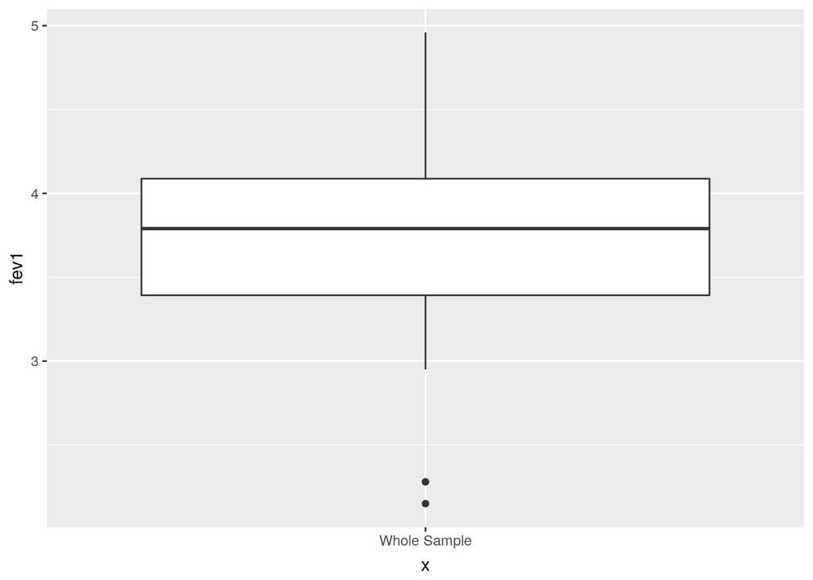

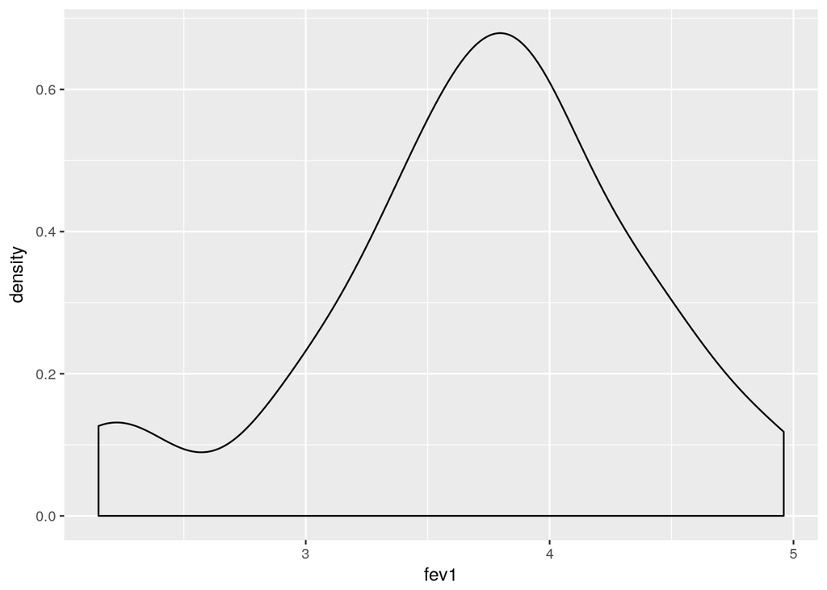

The following box-and-whisker chart displays the distribution of the individual values by group, and provides a more useful insight into the data than the one above. We see that there is a general downward trend along the categories.

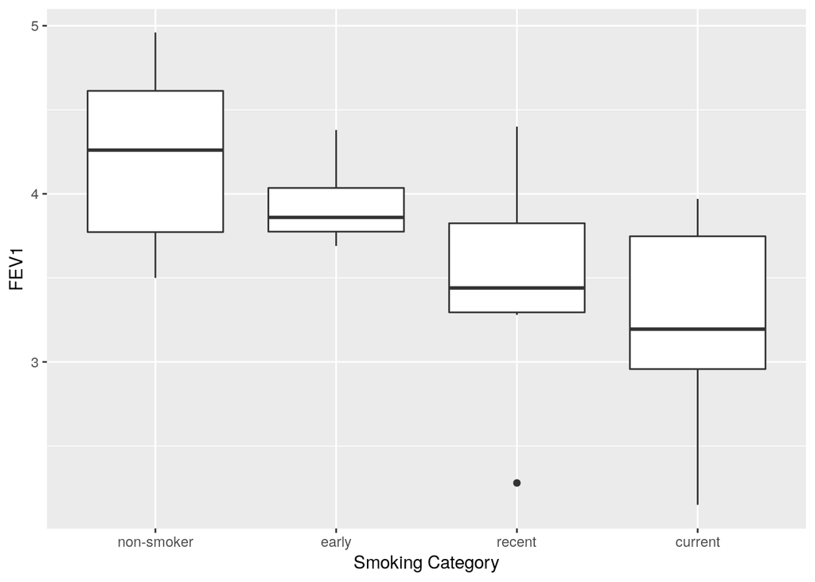

# Question 2:

*Carry out a one-way ANOVA to test the null hypothesis that FEV1 does not depend on smoking category.*

```
## $ANOVA
##   Effect DFn DFd        F          p p<.05       ges
## 1  cat.f   3  20 3.623135 0.03085325     * 0.3521093
##
## $`Levene's Test for Homogeneity of Variance`
##   DFn DFd       SSn      SSd        F         p p<.05
## 1   3  20 0.4522792 2.229833 1.352206 0.2859163
```

1. *Formulate your conclusion in plain English, and*

2. *report the percentage of explained variance.*

# Question 3:

1. *Use post-hoc Tukey HSD tests (R command: TukeyHSD) to compare all pairs of means among the four groups of smokers. Summarize point estimates and 95% confidence intervals in a Table or graphical display,and indicate which pairs of means are found to be significantly different.*

```r
###A summary of the Tukey model:####
summary(f.thsd)
```

```
##             Df Sum Sq Mean Sq F value Pr(>F)
## cat.f        3  3.689  1.2297   3.623 0.0309 *
## Residuals   20  6.788  0.3394
## ---
## Signif. codes:  0 '***' 0.001 '**' 0.01 '*' 0.05 '.' 0.1 ' ' 1
```

```r
###The Tukey model itself with point estimates####
thsd
```

```
##   Tukey multiple comparisons of means
##     95% family-wise confidence level
##
## Fit: aov(formula = fev1 ~ cat.f, data = f_clean)
##
## $cat.f
##                          diff         lwr       upr     p adj
## early-current       0.7183333 -0.22308912 1.6597558 0.1760748
## non-smoker-current  1.0000000  0.05857755 1.9414224 0.0348503
## recent-current      0.2400000 -0.70142245 1.1814224 0.8905477
## non-smoker-early    0.2816667 -0.65975578 1.2230891 0.8360677
## recent-early       -0.4783333 -1.41975578 0.4630891 0.5008038
## recent-non-smoker  -0.7600000 -1.70142245 0.1814224 0.1415657
```

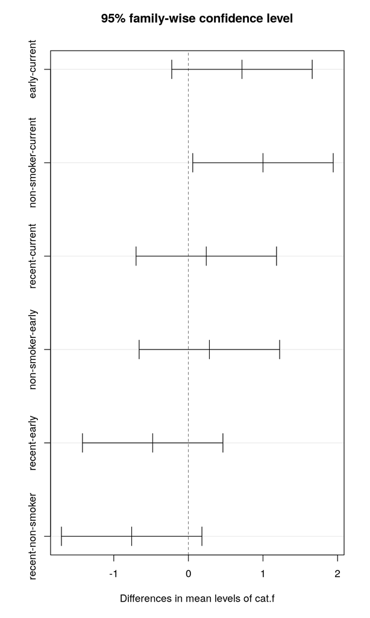

```r
###A graphical representation of the Tukey test####
plot(thsd)
```

Based on the Tukey HSD test, it would appear that only the difference between the **current smoker** and **non-smoker** groups is significant, since that is the only pair where the adjusted p-value is less than .05. We also see this in the graph, where the same pair is the only one where the confidence interval places it entirely above 0.

2. *Compare those results with results from all pairwise comparisons for mean FEV1 using the Bonferroni method (R command: pairwise.t.test).*

```
##
##  Pairwise comparisons using t tests with pooled SD
##
## data:  f_clean$fev1 and f_clean$cat.f
##
##            current early non-smoker
## early      0.272   -     -
## non-smoker 0.045   1.000 -
## recent     1.000   1.000 0.211
##
## P value adjustment method: bonferroni
```

We see the same result here, with only the pair **current/non-smoker** returning a p-value less than .05, and as such, is the only pair where we can assume a significant difference.

# Question 4:

*Is there any evidence for a linear or quadratic trend for mean FEV1 when considering smoking status as ordered factor levels: 1 < 2 < 3 < 4 (use the R command factor with the ordered = TRUE option*

```
##
## Call:
## lm(formula = fev1 ~ factor(cat.f, ordered = T), data = f_clean)
##
## Residuals:
##      Min       1Q   Median       3Q      Max
## -1.18000 -0.24208 -0.07417  0.44625  0.94000
##
## Coefficients:
##                              Estimate Std. Error t value Pr(>|t|)
## (Intercept)                    3.7096     0.1189  31.195  < 2e-16 ***
## factor(cat.f, ordered = T).L   0.2240     0.2378   0.942  0.35756
## factor(cat.f, ordered = T).Q  -0.7392     0.2378  -3.108  0.00554 **
## factor(cat.f, ordered = T).C  -0.1353     0.2378  -0.569  0.57582
## ---
## Signif. codes:  0 '***' 0.001 '**' 0.01 '*' 0.05 '.' 0.1 ' ' 1
##
## Residual standard error: 0.5826 on 20 degrees of freedom
## Multiple R-squared:  0.3521, Adjusted R-squared:  0.2549
## F-statistic: 3.623 on 3 and 20 DF,  p-value: 0.03085
```

This model would account for about 25.5% of the variance. A linear model of this data would produce the following graph along its categorical x-axis:

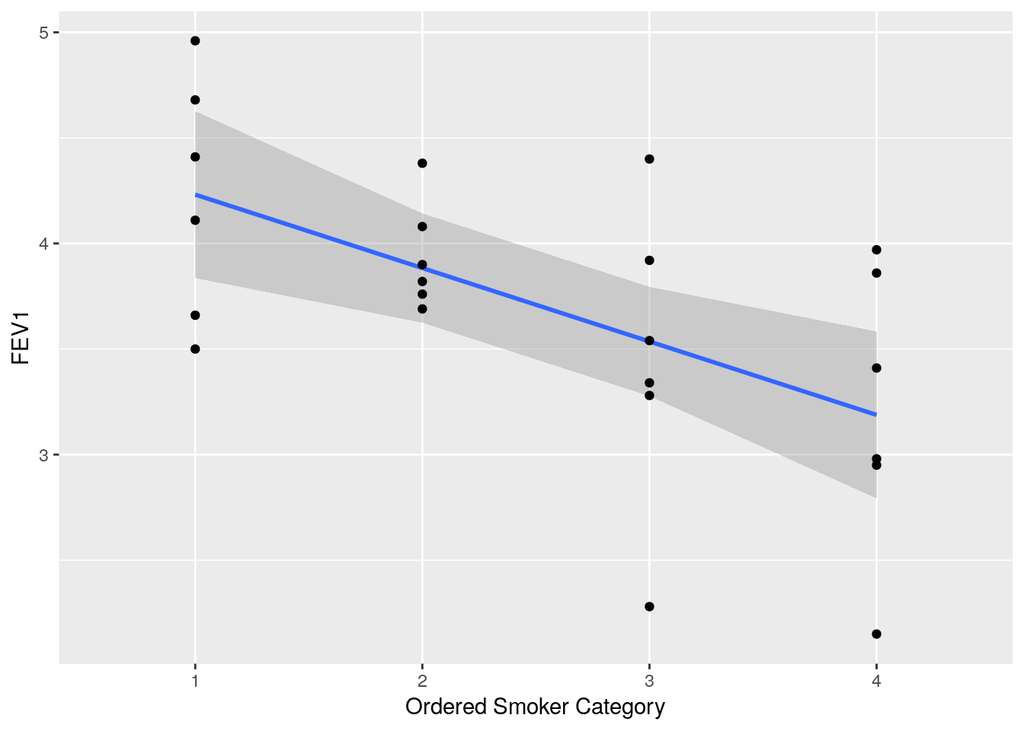

Based on the low p-value of the quadratic model above, there seems to be a downward quadratic trend in the data. This quadratic model (y~x^2) is presented below. It is important to note, however, that this graph is not strictly comparable to the one above, since it relies on numerical x-values instead of categorical ones.

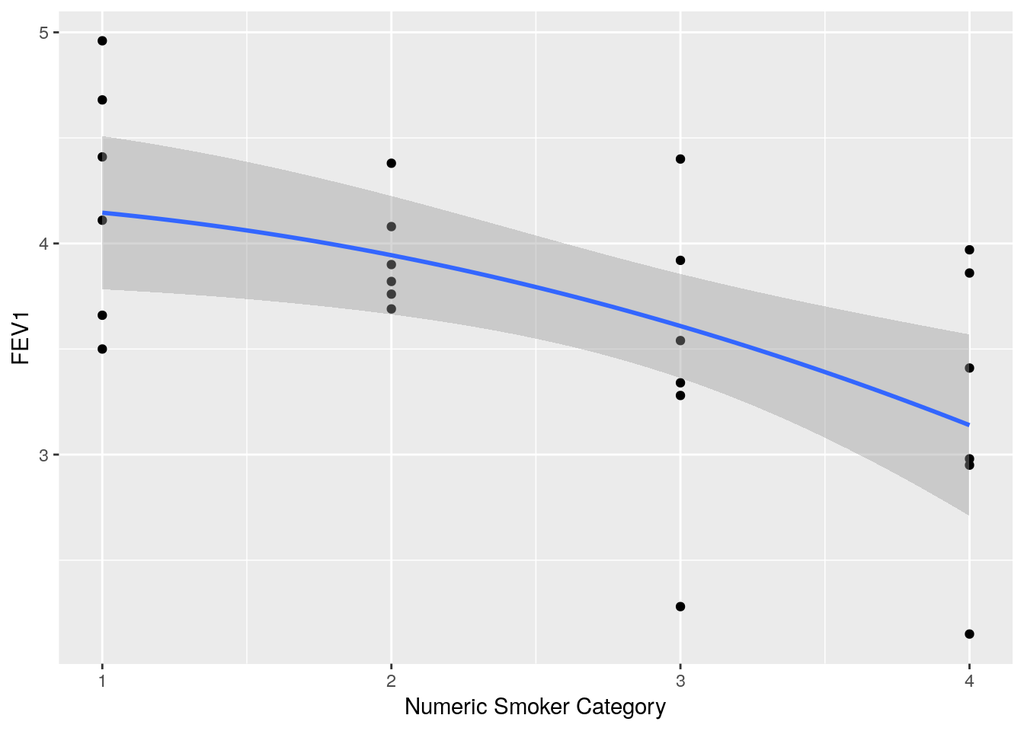

In addition, if we square our x-variable in addition to the y~x+x^2 model, we see a slowing trend. I’m not sure if this is actually meaningful at all, though.

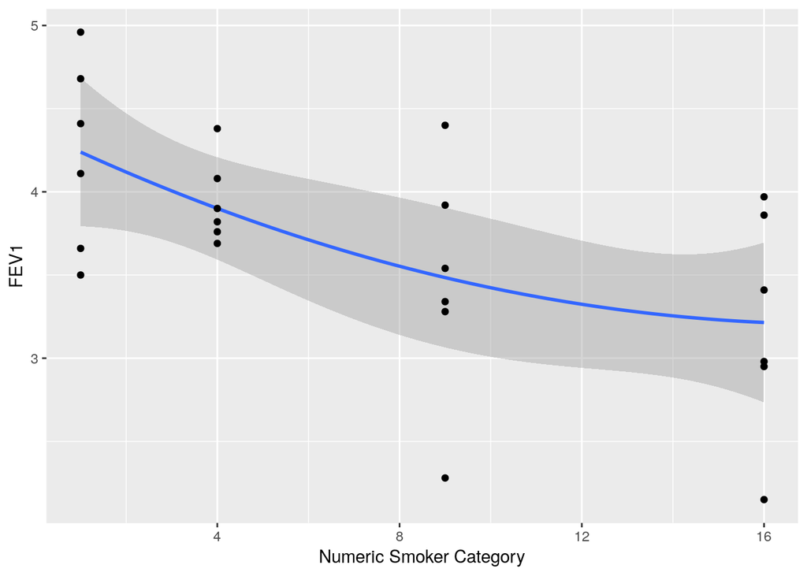

# Question 5:

1. *Compare the preceding results with the conclusion that would be reached by using a regression approach where one considers smoking status as a numerical variable, as well as its square, i.e., using the R command lm with a formula like FEV1 ~ smoking + I(smoking)^2.*

```
##
## Call:
## lm(formula = fev1 ~ cat + I(cat^2), data = lm_data)
##
## Residuals:
##      Min       1Q   Median       3Q      Max
## -1.24525 -0.22500 -0.01917  0.40562  0.87475
##
## Coefficients:
##             Estimate Std. Error t value Pr(>|t|)
## (Intercept)  4.63125    0.64885   7.138 4.87e-07 ***
## cat         -0.39992    0.59193  -0.676    0.507
## I(cat^2)     0.01042    0.11654   0.089    0.930
## ---
## Signif. codes:  0 '***' 0.001 '**' 0.01 '*' 0.05 '.' 0.1 ' ' 1
##
## Residual standard error: 0.5709 on 21 degrees of freedom
## Multiple R-squared:  0.3467, Adjusted R-squared:  0.2845
## F-statistic: 5.572 on 2 and 21 DF,  p-value: 0.01145
```

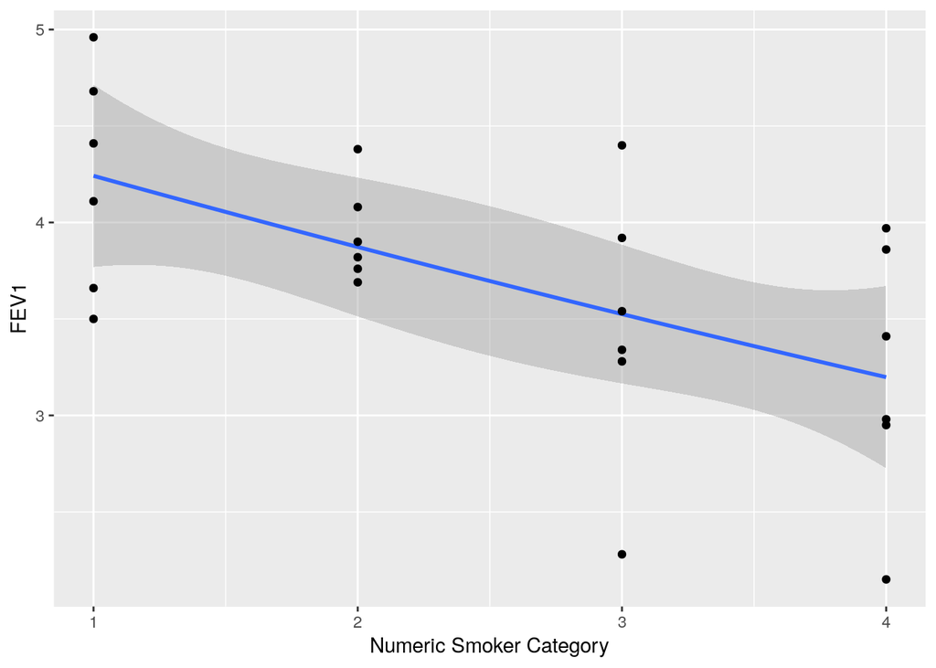

2. *What could explain the difference, if any?*

I honestly have no idea. Here is a model of y~x^2 which seems to account for even more of the variance than the y~x+x^2 model, but I do not understand why.

```
##
## Call:
## lm(formula = fev1 ~ I(cat^2), data = lm_data)
##
## Residuals:
##      Min       1Q   Median       3Q      Max
## -1.32895 -0.25803 -0.05667  0.34219  0.83065
##
## Coefficients:
##             Estimate Std. Error t value Pr(>|t|)
## (Intercept)  4.21273    0.19065   22.10  < 2e-16 ***
## I(cat^2)    -0.06709    0.02027   -3.31  0.00318 **
## ---
## Signif. codes:  0 '***' 0.001 '**' 0.01 '*' 0.05 '.' 0.1 ' ' 1
##
## Residual standard error: 0.5638 on 22 degrees of freedom
## Multiple R-squared:  0.3325, Adjusted R-squared:  0.3021
## F-statistic: 10.96 on 1 and 22 DF,  p-value: 0.003183
```